# Bayesian GLM Part3

- stan_ess (number of effective samples): the ratio of the number of effective samples (those not rejected by the sampler) to the number of samples provides an indication of the effectiveness (and efficiency) of the MCMC sampler. Ratios that are less than 0.5 for a parameter suggest that the sampler spent considerable time in difficult areas of the sampling domain and rejected more than half of the samples (replacing them with the previous effective sample).

  If the ratios are low, tightening the priors may help.

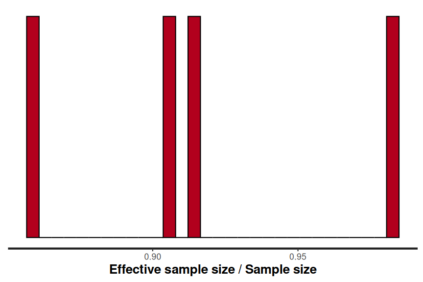

```r
stan_ess(peake_rstanarm3)
```

Ratios all very high.

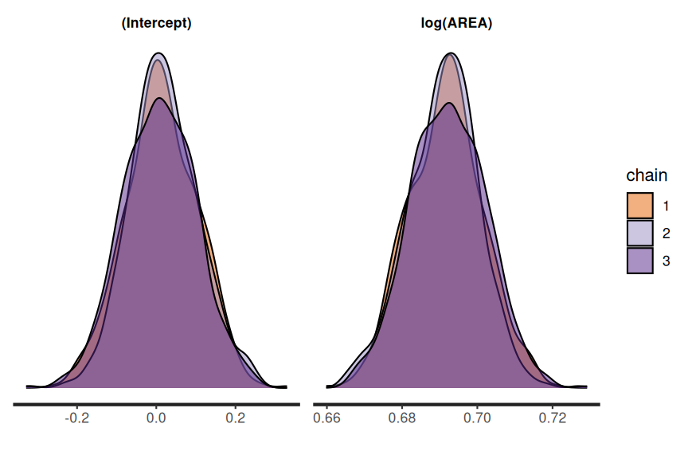

```r
stan_dens(peake_rstanarm3, separate_chains = TRUE)
```

**ggmcmc**

The `ggmean` package also has a set of MCMC diagnostic functions. Lets start with the MCMC diagnostics.

Of these, we will focus on:

- ggs_traceplot: this plots the estimates of each parameter over the post-warmup length of each MCMC chain. Each chain is plotted in a different colour, with each parameter in its own facet. Ideally, each **trace** should just look like noise without any discernible drift and each of the traces for a specific parameter should look the same (i.e, should not be displaced above or below any other trace for that parameter).

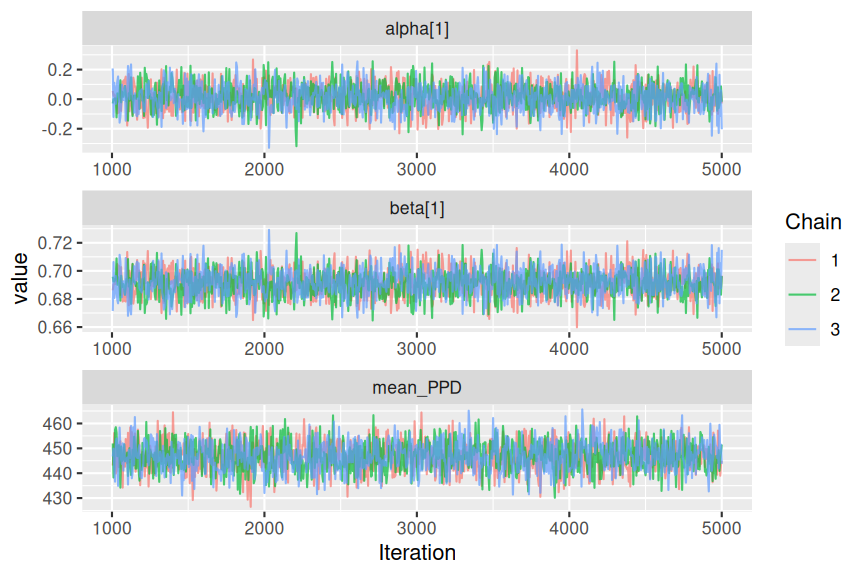

```r
peake_ggs <- ggs(peake_rstanarm3)
ggs_traceplot(peake_ggs)
```

The chains appear well mixed and very similar

- gss_autocorrelation (autocorrelation function): plots the autocorrelation between successive MCMC sample lags for each parameter and each chain

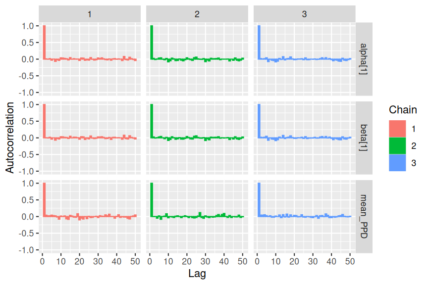

```r
ggs_autocorrelation(peake_ggs)
```

There is no evidence of autocorrelation in the MCMC samples

- stan_rhat: Rhat is a **scale reduction factor** measure of convergence between the chains. The closer the values are to 1, the more the chains have converged. Values greater than 1.05 indicate a lack of convergence. There will be an Rhat value for each parameter estimated.

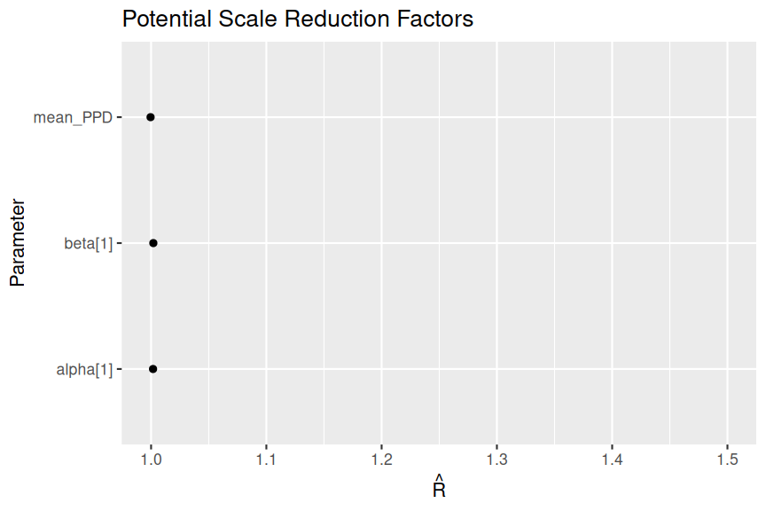

```r
ggs_Rhat(peake_ggs)
```

All Rhat values are below 1.05, suggesting the chains have converged.

- stan_ess (number of effective samples): the ratio of the number of effective samples (those not rejected by the sampler) to the number of samples provides an indication of the effectiveness (and efficiency) of the MCMC sampler. Ratios that are less than 0.5 for a parameter suggest that the sampler spent considerable time in difficult areas of the sampling domain and rejected more than half of the samples (replacing them with the previous effective sample).

  If the ratios are low, tightening the priors may help.

[figure not shown]

```r
ggs_effective(peake_ggs)
```

Ratios all very high.

**More diagnostics**

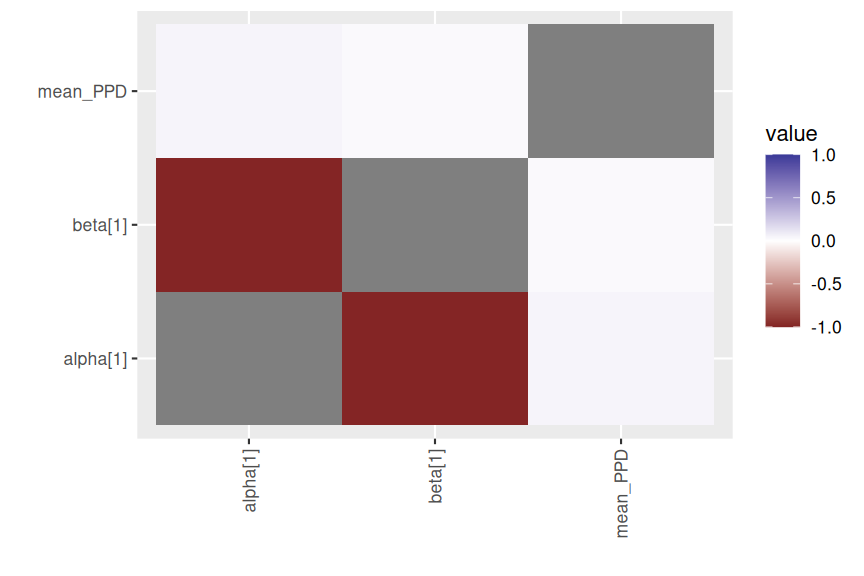

```r
ggs_crosscorrelation(peake_ggs)
```

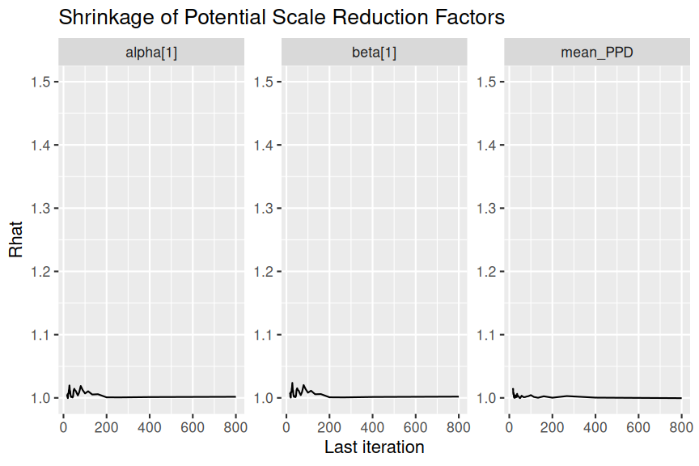

```r
ggs_grb(peake_ggs)
```

**brms**

**bayesplot**

The `bayesplot` package offers a range of MCMC diagnostics as well as Posterior Probability Checks (PPC), all of which have a convenient `plot()` interface. Lets start with the MCMC diagnostics.

**See list of available diagnostics by name**

```r
available_mcmc()
```

```
bayesplot MCMC module:
  mcmc_acf
  mcmc_acf_bar
  mcmc_areas
  mcmc_areas_ridges
  mcmc_combo
  mcmc_dens
  mcmc_dens_chains
  mcmc_dens_overlay
  mcmc_hex
  mcmc_hist
  mcmc_hist_by_chain
  mcmc_intervals
  mcmc_neff
  mcmc_neff_hist
  mcmc_nuts_acceptance
  mcmc_nuts_divergence
  mcmc_nuts_energy
  mcmc_nuts_stepsize
  mcmc_nuts_treedepth
  mcmc_pairs
  mcmc_parcoord
  mcmc_rank_ecdf
  mcmc_rank_hist
  mcmc_rank_overlay
  mcmc_recover_hist
  mcmc_recover_intervals
  mcmc_recover_scatter
  mcmc_rhat
  mcmc_rhat_hist
  mcmc_scatter
  mcmc_trace
  mcmc_trace_highlight
  mcmc_violin
```

Of these, we will focus on:

- trace: this plots the estimates of each parameter over the post-warmup length of each MCMC chain. Each chain is plotted in a different shade of blue, with each parameter in its own facet. Ideally, each **trace** should just look like noise without any discernible drift and each of the traces for a specific parameter should look the same (i.e, should not be displaced above or below any other trace for that parameter).

```
No divergences to plot.
```

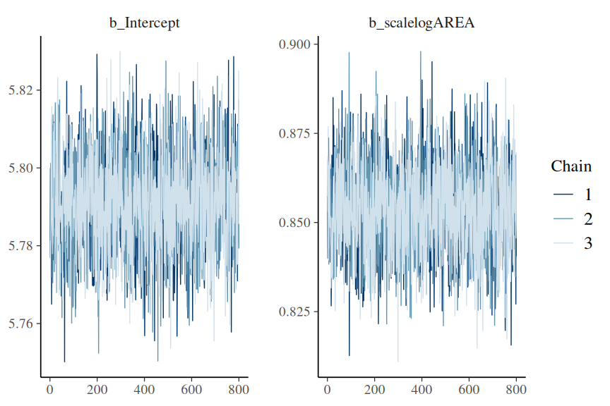

```r
mcmc_plot(peake_brm3, type = "trace")
```

The chains appear well mixed and very similar

- acf_bar (autocorrelation function): plots the autocorrelation between successive MCMC sample lags for each parameter and each chain

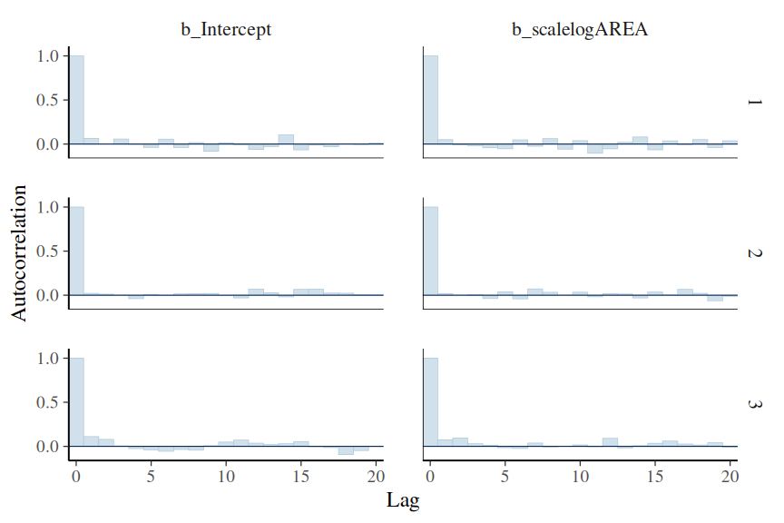

```r
mcmc_plot(peake_brm3, type = "acf_bar")
```

There is no evidence of autocorrelation in the MCMC samples

- rhat_hist: Rhat is a **scale reduction factor** measure of convergence between the chains. The closer the values are to 1, the more the chains have converged. Values greater than 1.05 indicate a lack of convergence. There will be an Rhat value for each parameter estimated.

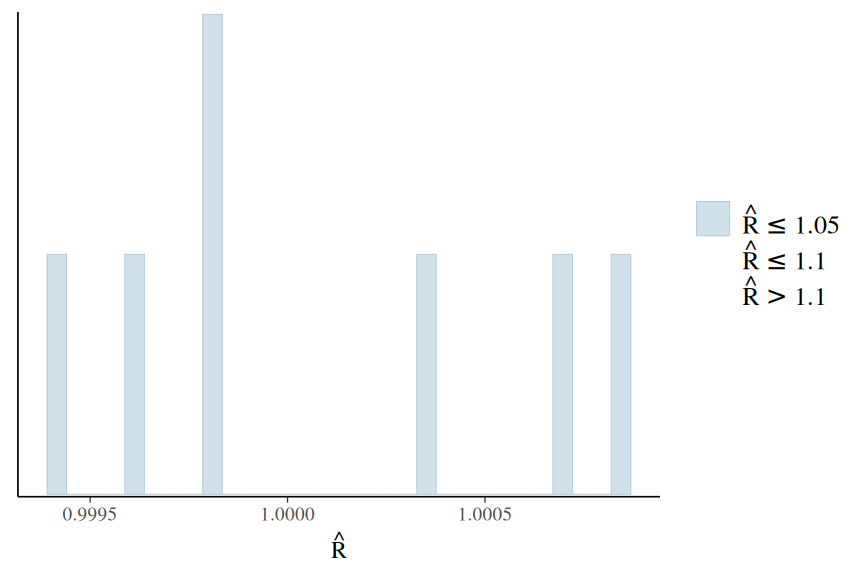

```r
mcmc_plot(peake_brm3, type = "rhat_hist")
```

All Rhat values are below 1.05, suggesting the chains have converged.

- neff_hist (number of effective samples): the ratio of the number of effective samples (those not rejected by the sampler) to the number of samples provides an indication of the effectiveness (and efficiency) of the MCMC sampler. Ratios that are less than 0.5 for a parameter suggest that the sampler spent considerable time in difficult areas of the sampling domain and rejected more than half of the samples (replacing them with the previous effective sample).

  If the ratios are low, tightening the priors may help.

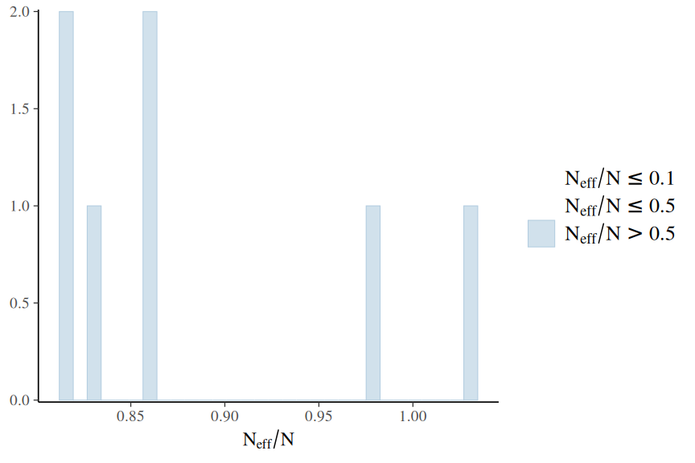

```r
mcmc_plot(peake_brm3, type = "neff_hist")
```

Ratios all very high.

**More diagnostics**

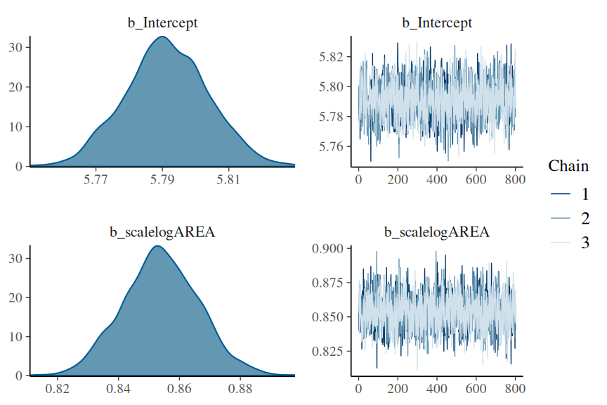

```r
mcmc_plot(peake_brm3, type = "combo")
```

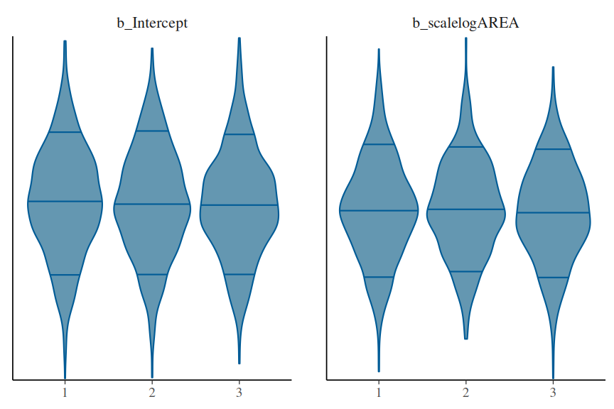

```r
mcmc_plot(peake_brm3, type = "violin")
```

**stan plots**

The `rstan` package offers a range of MCMC diagnostics. Lets start with the MCMC diagnostics.

Of these, we will focus on:

- stan_trace: this plots the estimates of each parameter over the post-warmup length of each MCMC chain. Each chain is plotted in a different colour, with each parameter in its own facet. Ideally, each **trace** should just look like noise without any discernible drift and each of the traces for a specific parameter should look the same (i.e, should not be displaced above or below any other trace for that parameter).

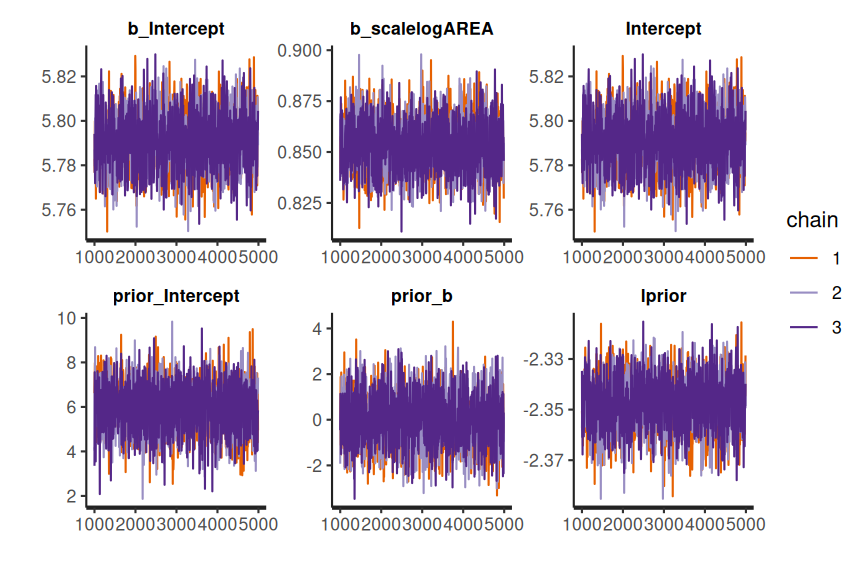

```r
stan_trace(peake_brm3$fit)
```

The chains appear well mixed and very similar

- stan_acf (autocorrelation function): plots the autocorrelation between successive MCMC sample lags for each parameter and each chain

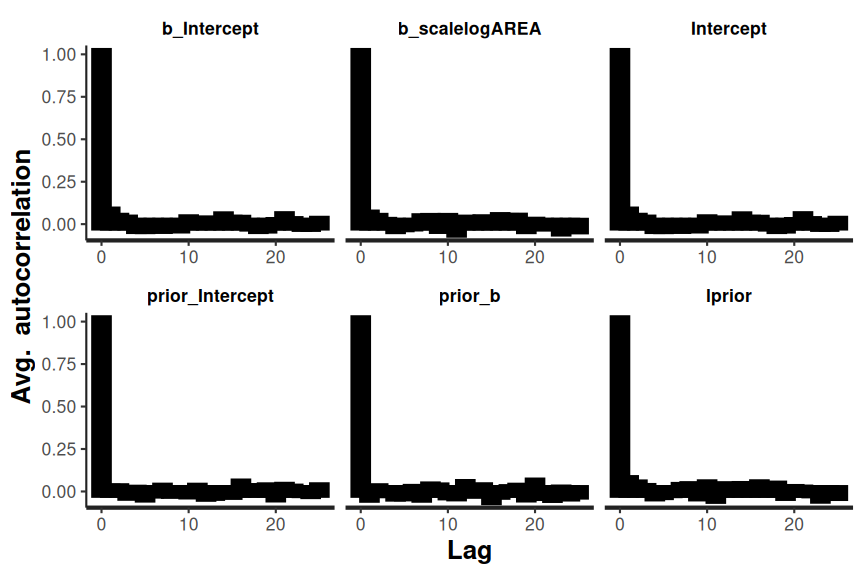

```r
stan_ac(peake_brm3$fit)
```

There is no evidence of autocorrelation in the MCMC samples

- stan_rhat: Rhat is a **scale reduction factor** measure of convergence between the chains. The closer the values are to 1, the more the chains have converged. Values greater than 1.05 indicate a lack of convergence. There will be an Rhat value for each parameter estimated.

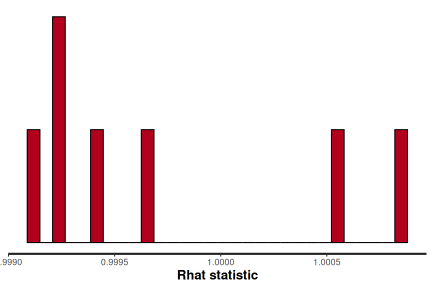

```r
stan_rhat(peake_brm3$fit)
```

All Rhat values are below 1.05, suggesting the chains have converged.

- stan_ess (number of effective samples): the ratio of the number of effective samples (those not rejected by the sampler) to the number of samples provides an indication of the effectiveness (and efficiency) of the MCMC sampler. Ratios that are less than 0.5 for a parameter suggest that the sampler spent considerable time in difficult areas of the sampling domain and rejected more than half of the samples (replacing them with the previous effective sample).

  If the ratios are low, tightening the priors may help.

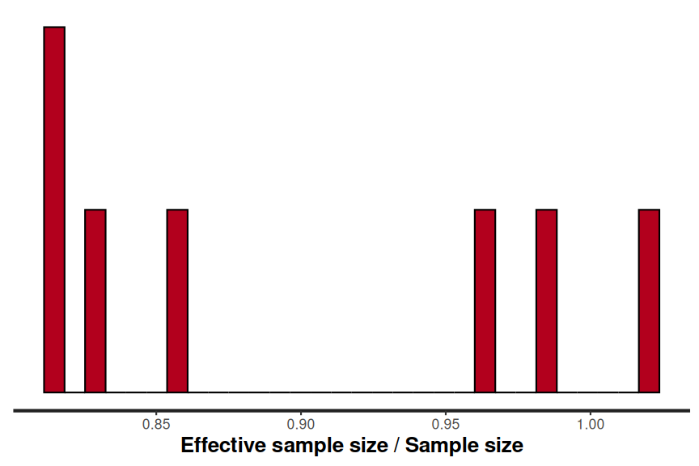

```r
stan_ess(peake_brm3$fit)
```

Ratios all very high.

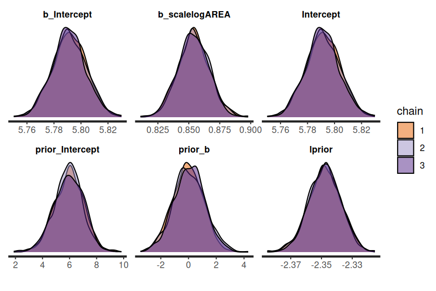

```r
stan_dens(peake_brm3$fit, separate_chains = TRUE)
```

**ggmcmc**

The `ggmean` package also has a set of MCMC diagnostic functions. Lets start with the MCMC diagnostics.

Of these, we will focus on:

- ggs_traceplot: this plots the estimates of each parameter over the post-warmup length of each MCMC chain. Each chain is plotted in a different colour, with each parameter in its own facet. Ideally, each **trace** should just look like noise without any discernible drift and each of the traces for a specific parameter should look the same (i.e, should not be displaced above or below any other trace for that parameter).

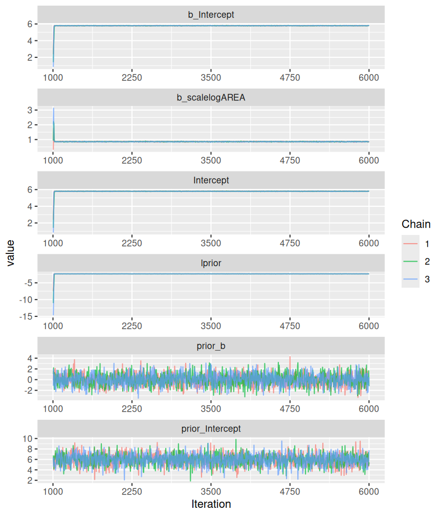

```r
peake_ggs <- ggs(peake_brm3)
ggs_traceplot(peake_ggs)
```

The chains appear well mixed and very similar

- gss_autocorrelation (autocorrelation function): plots the autocorrelation between successive MCMC sample lags for each parameter and each chain

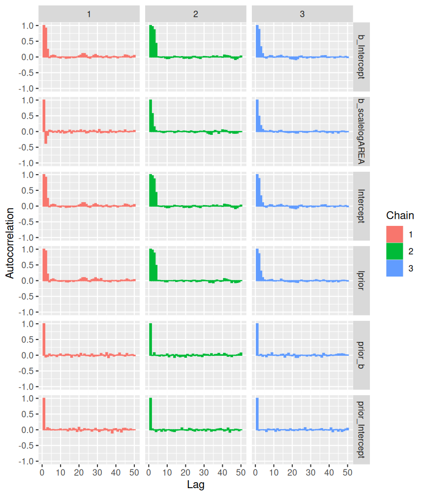

```r
ggs_autocorrelation(peake_ggs)
```

- stan_rhat: Rhat is a **scale reduction factor** measure of convergence between the chains. The closer the values are to 1, the more the chains have converged. Values greater than 1.05 indicate a lack of convergence. There will be an Rhat value for each parameter estimated.

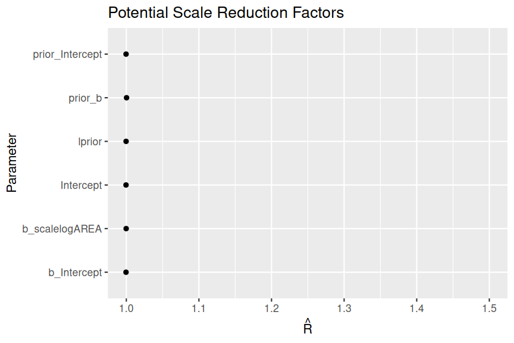

```r
ggs_Rhat(peake_ggs)
```

All Rhat values are below 1.05, suggesting the chains have converged.

- stan_ess (number of effective samples): the ratio of the number of effective samples (those not rejected by the sampler) to the number of samples provides an indication of the effectiveness (and efficiency) of the MCMC sampler. Ratios that are less than 0.5 for a parameter suggest that the sampler spent considerable time in difficult areas of the sampling domain and rejected more than half of the samples (replacing them with the previous effective sample).

  If the ratios are low, tightening the priors may help.

[figure not shown]

```r
ggs_effective(peake_ggs)
```

Ratios all very high.

**More diagnostics**

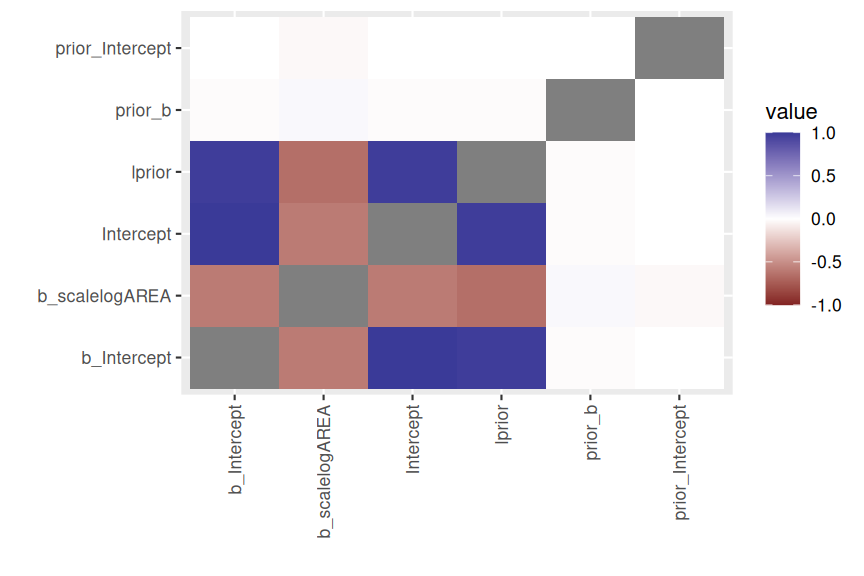

```r
ggs_crosscorrelation(peake_ggs)
```

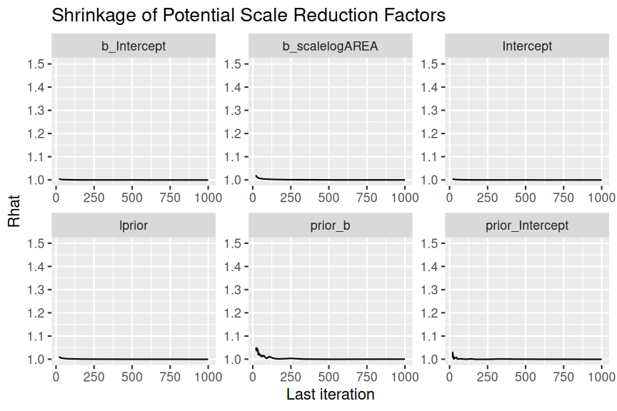

```r
ggs_grb(peake_ggs)
```

# 7 Model validation

**rstanarm**

**pp check**

Post predictive checks provide additional diagnostics about the fit of the model. Specifically, they provide a comparison between predictions drawn from the model and the observed data used to train the model.

**See list of available diagnostics by name**

```r
available_ppc()
```

```
bayesplot PPC module:
  ppc_bars
  ppc_bars_grouped
  ppc_boxplot
  ppc_dens
  ppc_dens_overlay
  ppc_dens_overlay_grouped
  ppc_dots
  ppc_ecdf_overlay
  ppc_ecdf_overlay_grouped
  ppc_error_binned
  ppc_error_hist
  ppc_error_hist_grouped
  ppc_error_scatter
  ppc_error_scatter_avg
  ppc_error_scatter_avg_grouped
  ppc_error_scatter_avg_vs_x
  ppc_freqpoly
  ppc_freqpoly_grouped
  ppc_hist
  ppc_intervals
  ppc_intervals_grouped
  ppc_km_overlay
  ppc_km_overlay_grouped
  ppc_loo_intervals
  ppc_loo_pit_ecdf
  ppc_loo_pit_overlay
  ppc_loo_pit_qq
  ppc_loo_ribbon
  ppc_pit_ecdf
  ppc_pit_ecdf_grouped
  ppc_ribbon
  ppc_ribbon_grouped
  ppc_rootogram
  ppc_scatter
  ppc_scatter_avg
  ppc_scatter_avg_grouped
  ppc_stat
  ppc_stat_2d
  ppc_stat_freqpoly
  ppc_stat_freqpoly_grouped
  ppc_stat_grouped
  ppc_violin_grouped
```

- dens_overlay: plots the density distribution of the observed data (black line) overlayed ontop of 50 density distributions generated from draws from the model (light blue). Ideally, the 50 realisations should be roughly consistent with the observed data.

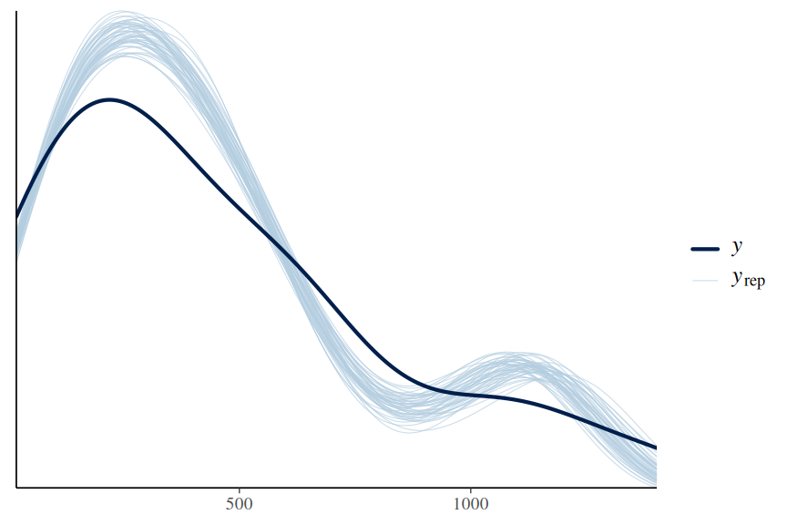

```r
pp_check(peake_rstanarm3, plotfun = "dens_overlay")
```

The model draws appear deviate from the observed data.

- error_scatter_avg: this plots the observed values against the average residuals. Similar to a residual plot, we do not want to see any patterns in this plot. There is some pattern remaining in these residuals.

```r
# pp_check(peake_rstanarm3, plotfun='error_scatter_avg')
```

- error_scatter_avg_vs_x: this is similar to a regular residual plot and as such should be interpreted as such. Again, this is not interpretable for binary data.

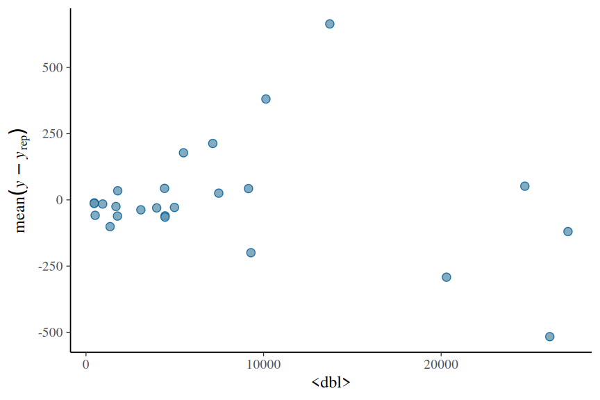

```r
pp_check(peake_rstanarm3, x = peake$AREA, plotfun = "error_scatter_avg_vs_x")
```

- intervals: plots the observed data overlayed ontop of posterior predictions associated with each level of the predictor. Ideally, the observed data should all fall within the predictive intervals.

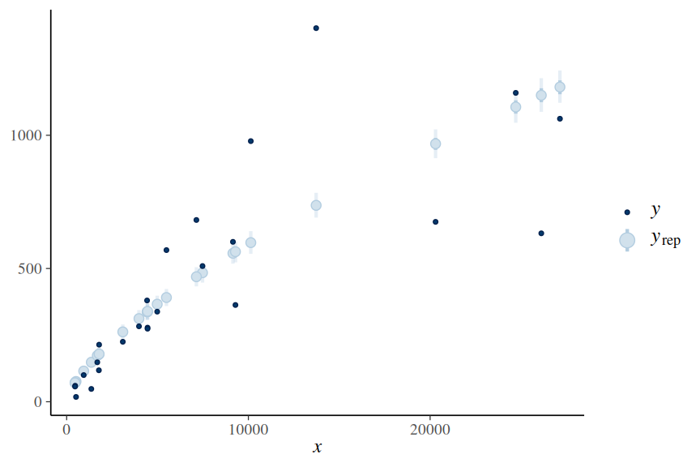

```r
pp_check(peake_rstanarm3, x = peake$AREA, plotfun = "intervals")
```

The modelled preditions seem to underestimate the uncertainty with increasing mussel clump area.

- ribbon: this is just an alternative way of expressing the above plot.

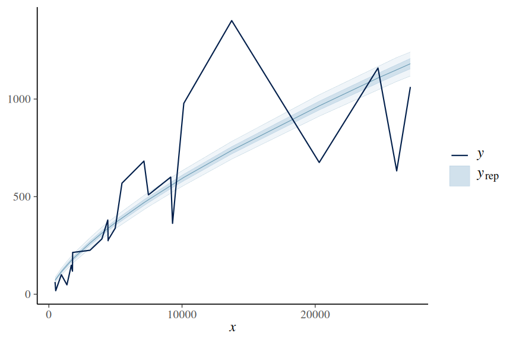

```r
pp_check(peake_rstanarm3, x = peake$AREA, plotfun = "ribbon")
```

The `shinystan` package allows the full suite of MCMC diagnostics and posterior predictive checks to be accessed via a web interface.

```r
# library(shinystan)
# launch_shinystan(peake_rstanarm3)
```

**DHARMa residuals**

DHARMa residuals provide very useful diagnostics. Unfortunately, we cannot directly use the `simulateResiduals()` function to generate the simulated residuals. However, if we are willing to calculate some of the components ourself, we can still obtain the simulated residuals from the fitted stan model.

We need to supply:

- simulated (predicted) responses associated with each observation.
- observed values
- fitted (predicted) responses (averaged) associated with each observation

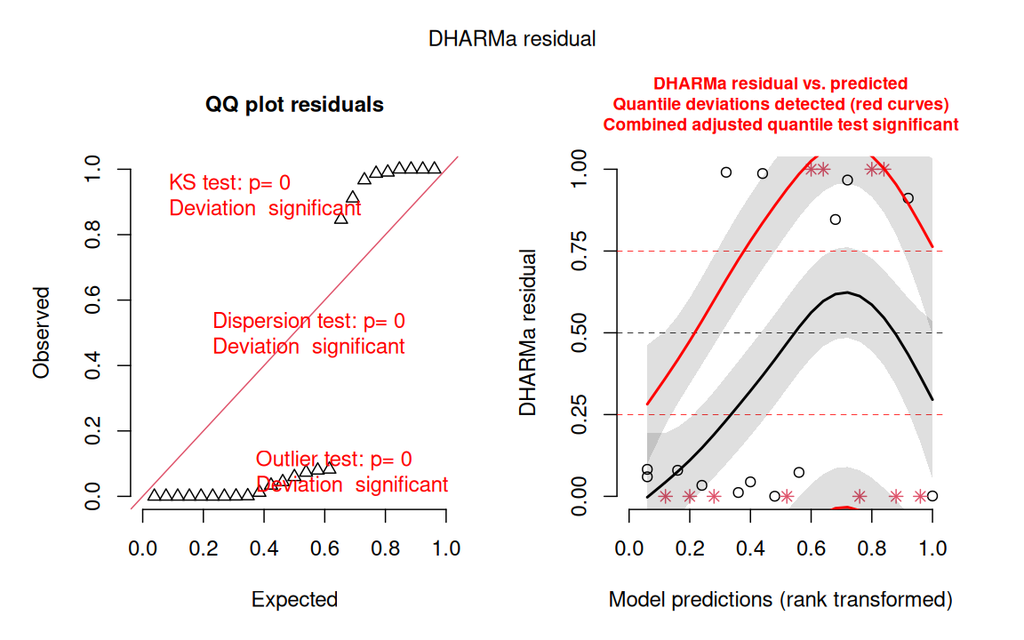

```r
preds <- posterior_predict(peake_rstanarm3, ndraws = 250, summary = FALSE)
peake_resids <- createDHARMa(
  simulatedResponse = t(preds),
  observedResponse = peake$INDIV,
  fittedPredictedResponse = apply(preds, 2, median),
  integerResponse = TRUE
)
plot(peake_resids)
```

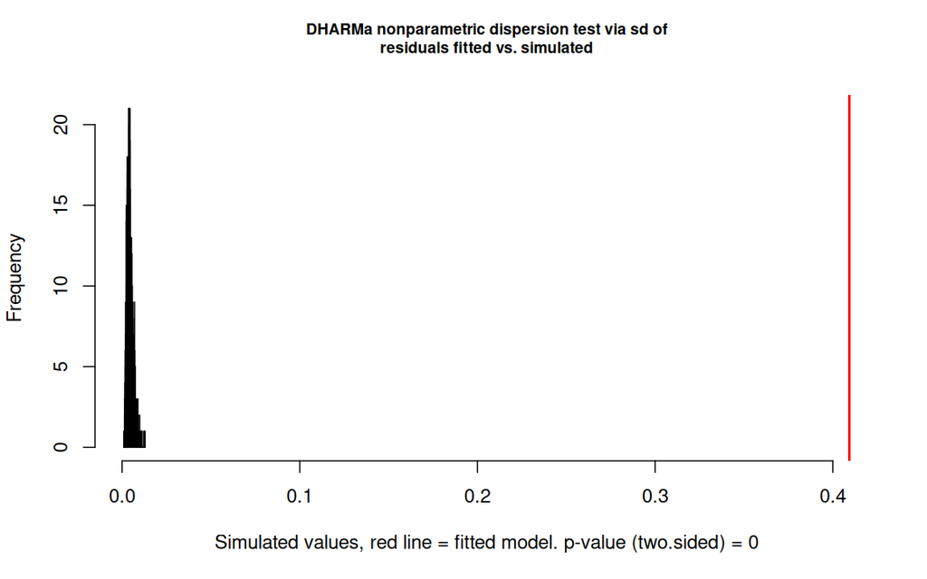

```
    DHARMa nonparametric dispersion test via sd of residuals fitted vs.
    simulated

data:  simulationOutput
dispersion = 95.939, p-value < 2.2e-16
alternative hypothesis: two.sided
```

```r
peake_resids |> testDispersion()
```

**Conclusions:**

- the simulated residuals suggest a general lack of fit due to overdispersion and outliers
- perhaps we should explore a negative binomial model

**brms**

**pp check**

Post predictive checks provide additional diagnostics about the fit of the model. Specifically, they provide a comparison between predictions drawn from the model and the observed data used to train the model.

**See list of available diagnostics by name**

```r
available_ppc()
```

```
bayesplot PPC module:
  ppc_bars
  ppc_bars_grouped
  ppc_boxplot
  ppc_dens
  ppc_dens_overlay
  ppc_dens_overlay_grouped
  ppc_dots
  ppc_ecdf_overlay
  ppc_ecdf_overlay_grouped
  ppc_error_binned
  ppc_error_hist
  ppc_error_hist_grouped
  ppc_error_scatter
  ppc_error_scatter_avg
  ppc_error_scatter_avg_grouped
  ppc_error_scatter_avg_vs_x
  ppc_freqpoly
  ppc_freqpoly_grouped
  ppc_hist
  ppc_intervals
  ppc_intervals_grouped
  ppc_km_overlay
  ppc_km_overlay_grouped
  ppc_loo_intervals
  ppc_loo_pit_ecdf
  ppc_loo_pit_overlay
  ppc_loo_pit_qq
  ppc_loo_ribbon
  ppc_pit_ecdf
  ppc_pit_ecdf_grouped
  ppc_ribbon
  ppc_ribbon_grouped
  ppc_rootogram
  ppc_scatter
  ppc_scatter_avg
  ppc_scatter_avg_grouped
  ppc_stat
  ppc_stat_2d
  ppc_stat_freqpoly
  ppc_stat_freqpoly_grouped
  ppc_stat_grouped
  ppc_violin_grouped
```

- dens_overlay: plots the density distribution of the observed data (black line) overlayed ontop of 50 density distributions generated from draws from the model (light blue). Ideally, the 50 realisations should be roughly consistent with the observed data.

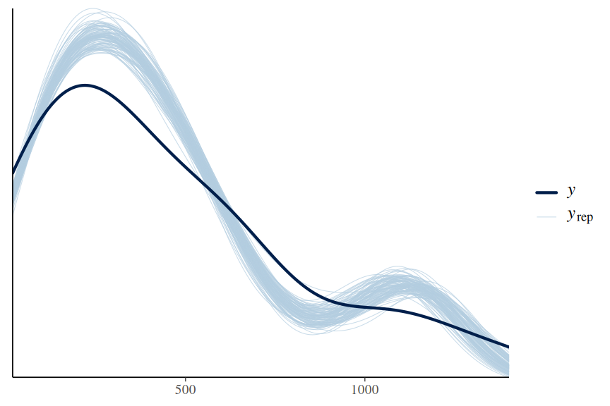

```r
pp_check(peake_brm3, type = "dens_overlay", ndraws = 100)
```

The model draws appear deviate from the observed data.

- error_scatter_avg: this plots the observed values against the average residuals. Similar to a residual plot, we do not want to see any patterns in this plot. There is some pattern remaining in these residuals.

```r
# pp_check(peake_brm3, type='error_scatter_avg')
```

- error_scatter_avg_vs_x: this is similar to a regular residual plot and as such should be interpreted as such. Again, this is not interpretable for binary data.

```
Using all posterior draws for ppc type 'error_scatter_avg_vs_x' by default.
```

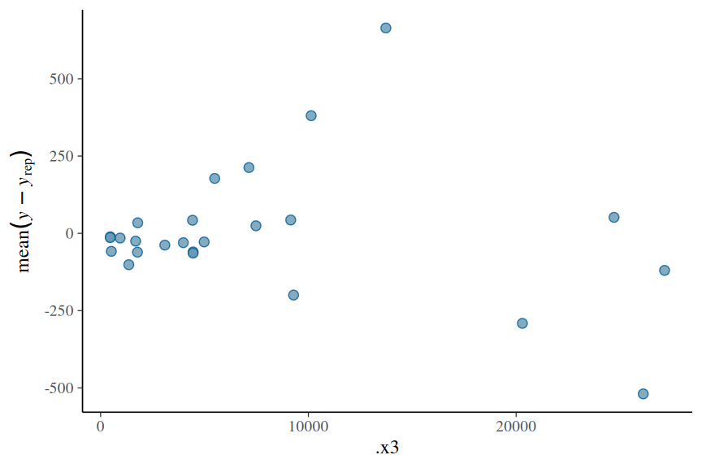

```r
pp_check(peake_brm3, x = "AREA", type = "error_scatter_avg_vs_x")
```

- intervals: plots the observed data overlayed ontop of posterior predictions associated with each level of the predictor. Ideally, the observed data should all fall within the predictive intervals.

```
Using all posterior draws for ppc type 'intervals' by default.
```

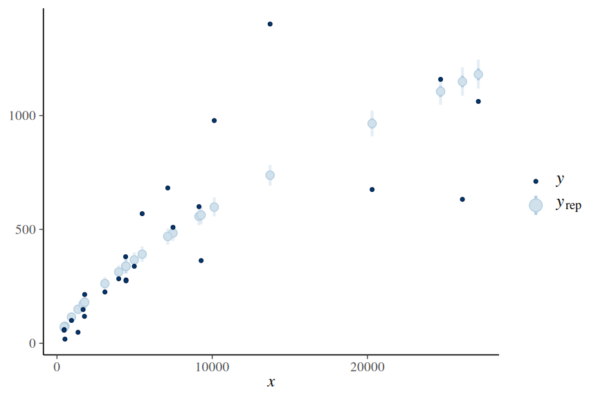

```r
pp_check(peake_brm3, x = "AREA", type = "intervals")
```

The modelled preditions seem to underestimate the uncertainty with increasing mussel clump area.

- ribbon: this is just an alternative way of expressing the above plot.

```
Using all posterior draws for ppc type 'ribbon' by default.
```

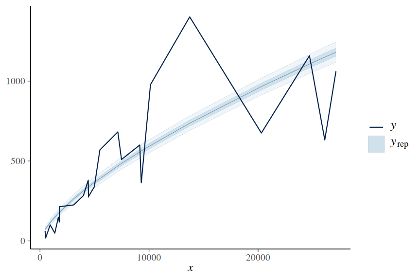

```r
pp_check(peake_brm3, x = "AREA", type = "ribbon")
```

The `shinystan` package allows the full suite of MCMC diagnostics and posterior predictive checks to be accessed via a web interface.

```r
# library(shinystan)
# launch_shinystan(peake_brm3)
```

**DHARMa residuals**

DHARMa residuals provide very useful diagnostics. Unfortunately, we cannot directly use the `simulateResiduals()` function to generate the simulated residuals. However, if we are willing to calculate some of the components ourself, we can still obtain the simulated residuals from the fitted stan model.

We need to supply:

- simulated (predicted) responses associated with each observation.
- observed values
- fitted (predicted) responses (averaged) associated with each observation

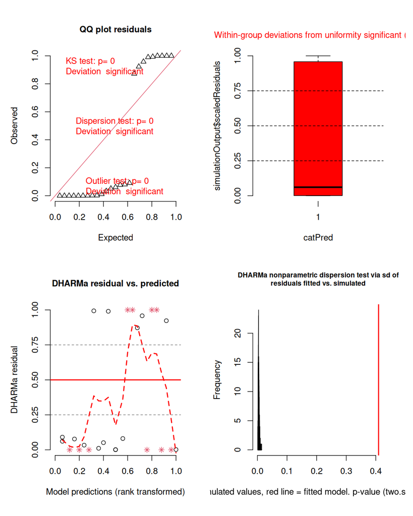

```r
peake_resids <- make_brms_dharma_res(peake_brm3, integerResponse = FALSE)
wrap_elements(~ testUniformity(peake_resids)) +
  wrap_elements(~ plotResiduals(peake_resids, form = factor(rep(1, nrow(peake))))) +
  wrap_elements(~ plotResiduals(peake_resids, quantreg = FALSE)) +
  wrap_elements(~ testDispersion(peake_resids))
```

**Conclusions:**

- the simulated residuals suggest a general lack of fit due to overdispersion and outliers
- perhaps we should explore a negative binomial model

And the old (and now incorrect) way….

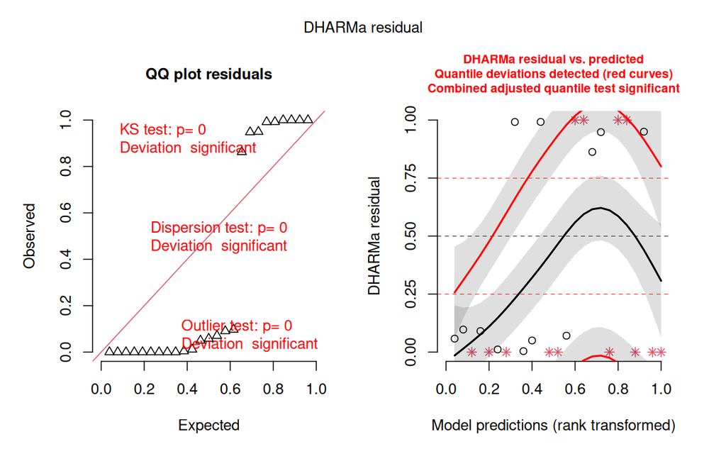

```r
preds <- posterior_predict(peake_brm3, ndraws = 250, summary = FALSE)
peake_resids <- createDHARMa(
  simulatedResponse = t(preds),
  observedResponse = peake$INDIV,
  fittedPredictedResponse = apply(preds, 2, median),
  integerResponse = TRUE
)
plot(peake_resids)
```

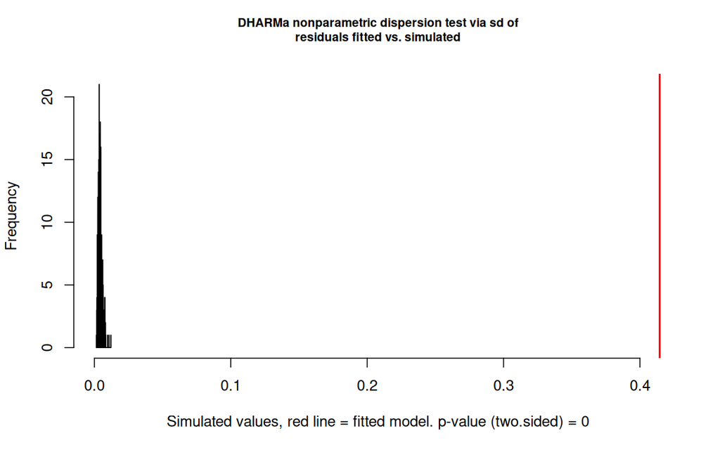

```
    DHARMa nonparametric dispersion test via sd of residuals fitted vs.
    simulated

data:  simulationOutput
dispersion = 98.037, p-value < 2.2e-16
alternative hypothesis: two.sided
```

```r
peake_resids |> testDispersion()
```

# 8 Fit Negative Binomial rstanarm

**rstanarm**

**Fit the model**

```r
peake_rstanarm4 <- stan_glm(INDIV ~ log(AREA),
  data = peake,
  family = neg_binomial_2(),
  prior_intercept = normal(6, 2.8, autoscale = FALSE),
  prior = normal(0, 2.3, autoscale = FALSE),
  prior_aux = rstanarm::exponential(rate = 1, autoscale = FALSE),
  iter = 5000, warmup = 1000,
  chains = 3, thin = 5, refresh = 0
)
```

**Plotting prior and posterior**

```
Drawing from prior...
```

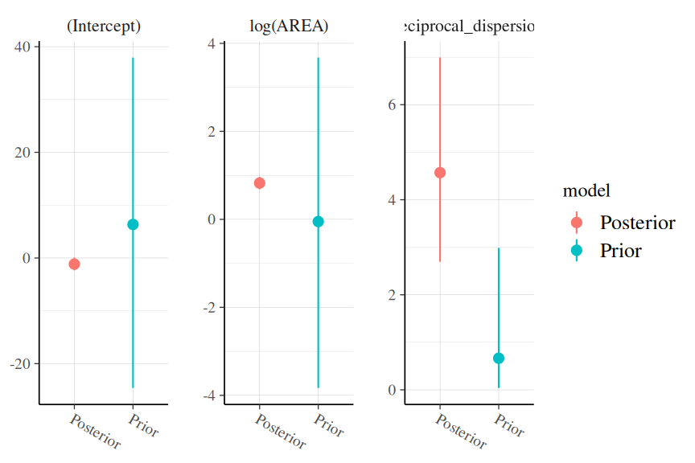

```r
posterior_vs_prior(peake_rstanarm4,
  color_by = "vs", group_by = TRUE,
  facet_args = list(scales = "free_y")
)
```

**Conclusions:**

```
Data points may overlap. Use the `jitter` argument to add some amount of
  random variation to the location of data points and avoid overplotting.
```

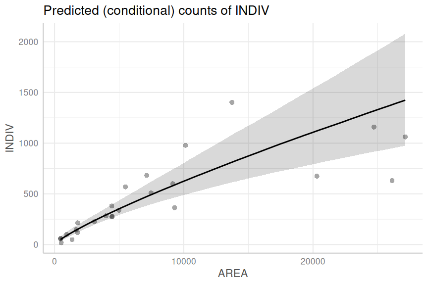

```r
## ggemmeans(peake_rstanarm4,  ~AREA) |> plot(show_data=TRUE)
ggpredict(peake_rstanarm4, ~AREA) |> plot(show_data = TRUE)
```

**MCMC chain and posterior checks**

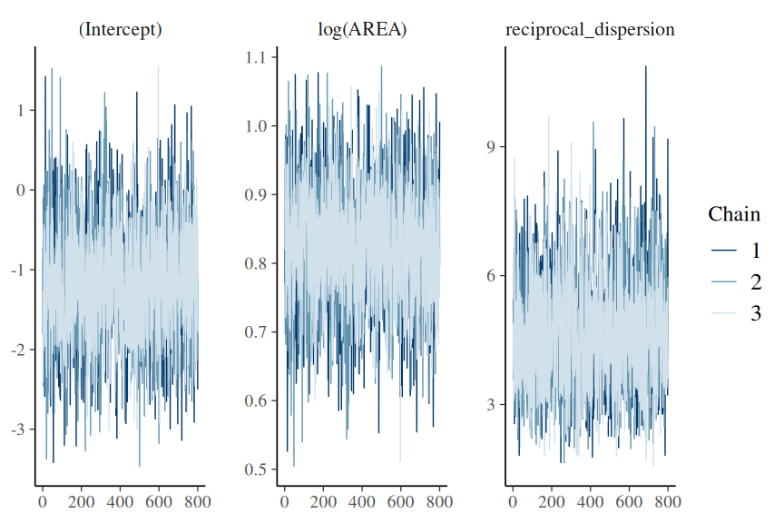

```r
plot(peake_rstanarm4, plotfun = "mcmc_trace")
```

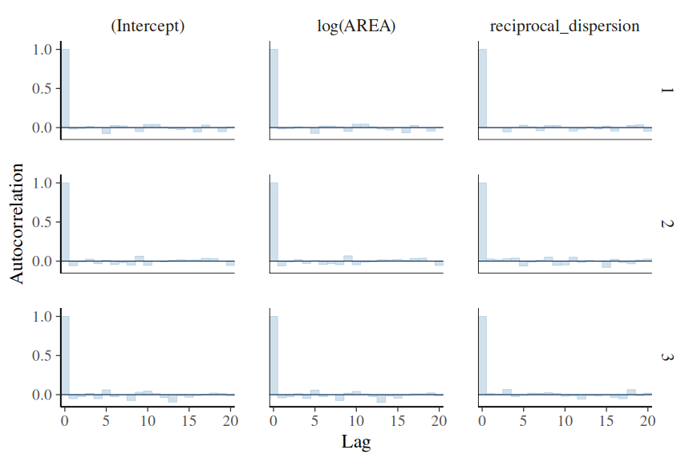

```r
plot(peake_rstanarm4, "acf_bar")
```

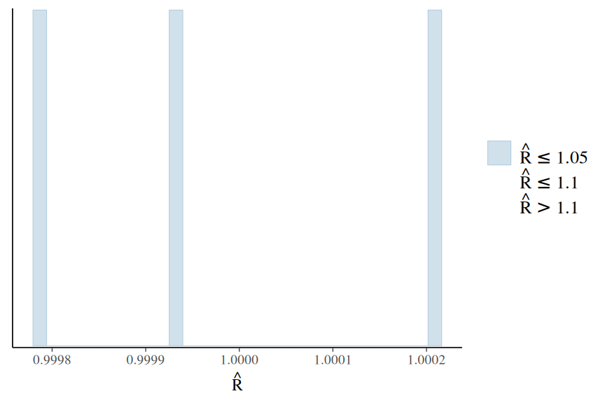

```r
plot(peake_rstanarm4, "rhat_hist")
```

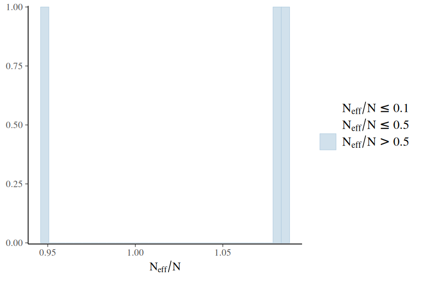

```r
plot(peake_rstanarm4, "neff_hist")
```

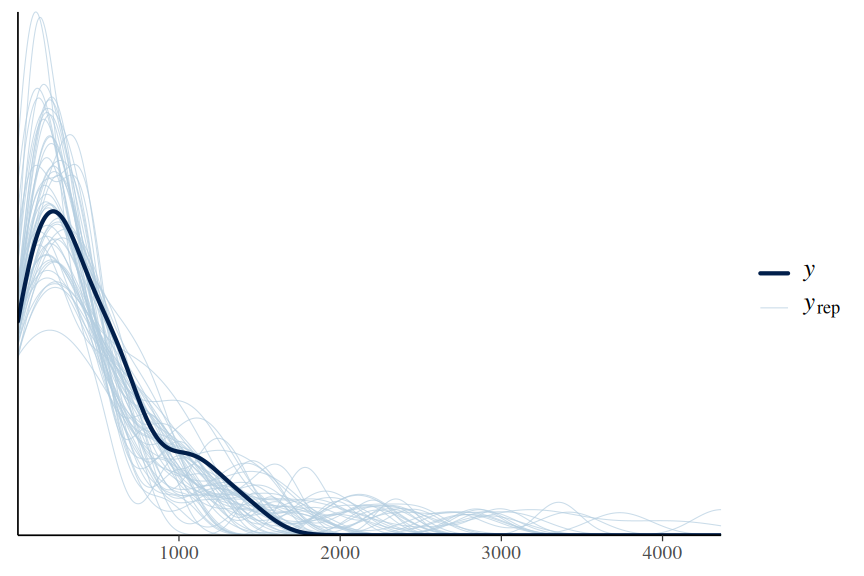

```r
pp_check(peake_rstanarm4, x = peake$AREA, plotfun = "dens_overlay")
```

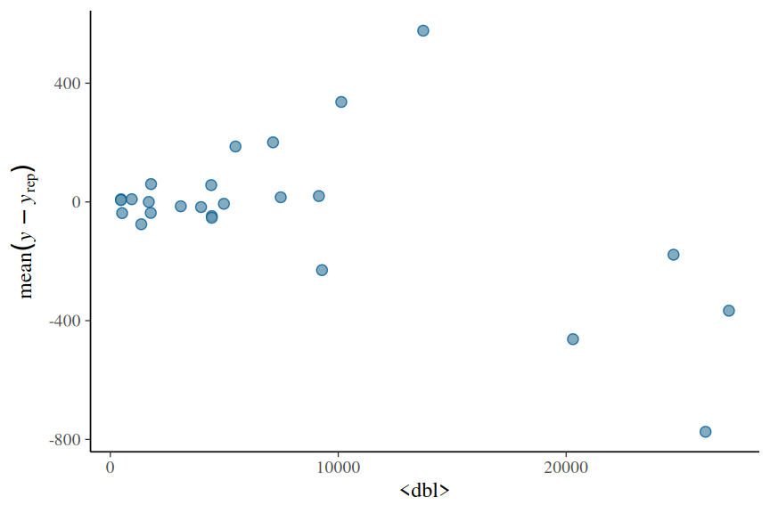

```r
pp_check(peake_rstanarm4, x = peake$AREA, plotfun = "error_scatter_avg_vs_x")
```

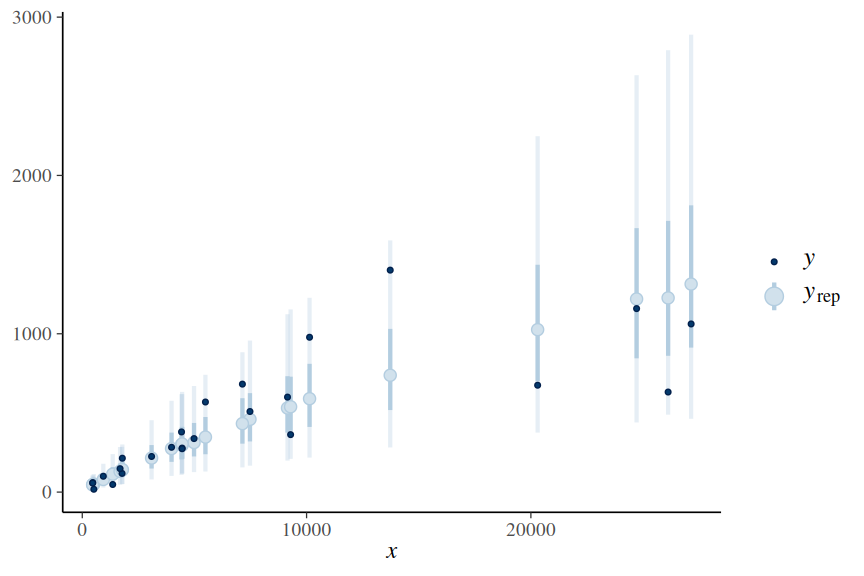

```r
pp_check(peake_rstanarm4, x = peake$AREA, plotfun = "intervals")
```

**DHARMa residuals**

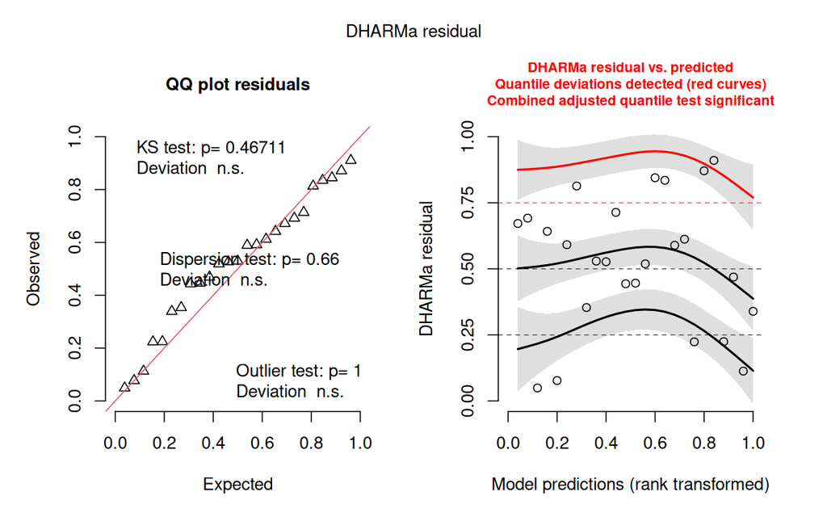

```r
preds <- posterior_predict(peake_rstanarm4, ndraws = 250, summary = FALSE)
peake_resids <- createDHARMa(
  simulatedResponse = t(preds),
  observedResponse = peake$INDIV,
  fittedPredictedResponse = apply(preds, 2, median),
  integerResponse = TRUE
)
plot(peake_resids)
```

**LOOIC**

Different models can be compared via information criterion. LOO (Leave One Out) IC is similar to AIC except that AIC does not consider priors and assumes that the posterior likelihood is multivariate normal. LOO AIC does not and integrates over all uncertainty.

- ELPD: is the theoretical expected log pointwise predictive density for a new dataset and can be estimated via leave-one-out cross-validation.
- `elpd_loo`: is the Bayesian LOO estimate of ELPD
- `SE` of `elpd_loo`: is the Monte Carlo standard error is the estimate for the computational accuracy of MCMC and importance sampling used to compute `elpd_loo`
- `p_loo`: is the difference between `elpd_loo` and the estimated from non-cross validated ELPD and therefore is a measure of the relative extra difficulty of predicting new data compared to the observed data. It can also be a meaure of the effective number of parameters:
  - in a well behaved model, `p_loo` will be less than the number of estimated parameters and the total sample size.
  - in a misspecified model, `p_loo` will be greater than the number of estimated parameters and the total sample size.
- `Pareto k`: is a relative measure of the influence of each observation as well as the accuracy with which the associated leave one out calculations can be estimated.
  - when `k < 0.5`: the corresponding components can be accurately estimated
  - when `0.5 < k < 0.7`: the accuracy is lower but still acceptable
  - when `k>0.7`: the accuracy is too low and `elpd_loo` is unreliable. This can also suggest a misspecified model.

More information about the above can be gleaned from [https://mc-stan.org/loo/reference/loo-glossary.html].

Start with the Poisson model

```r
(peake_rstanarm3.loo <- loo(peake_rstanarm3))
```

```
Computed from 2400 by 25 log-likelihood matrix.

         Estimate    SE
elpd_loo   -930.0 298.1
p_loo       120.2  46.9
looic      1860.0 596.1
------
MCSE of elpd_loo is NA.
MCSE and ESS estimates assume MCMC draws (r_eff in [0.9, 1.0]).

Pareto k diagnostic values:
                         Count Pct.    Min. ESS
(-Inf, 0.7]   (good)     18    72.0%   44
   (0.7, 1]   (bad)       3    12.0%   <NA>
   (1, Inf)   (very bad)  4    16.0%   <NA>
See help('pareto-k-diagnostic') for details.
```

**Conclusions:**

- `p_loo` is substantially higher than the number of estimated parameters
- there are some `Pareto k` values identified as bad or even very bad

Now for the Negative Binomial model

```r
(peake_rstanarm4.loo <- loo(peake_rstanarm4))
```

```
Computed from 2400 by 25 log-likelihood matrix.

         Estimate   SE
elpd_loo   -156.8  5.4
p_loo         1.9  0.5
looic       313.5 10.7
------
MCSE of elpd_loo is 0.0.
MCSE and ESS estimates assume MCMC draws (r_eff in [0.9, 1.1]).

All Pareto k estimates are good (k < 0.7).
See help('pareto-k-diagnostic') for details.
```

**Conclusions:**

- `p_loo` is lower than the number of estimated parameters
- there are no bad `Pareto k` values

We can also compare the models.

The difference in Expected Log Pointwise Probability Density (`elpd_dff`) computes the difference in `elpd_loo` of two models (expressed relative to the higher model). The difference in `elpd_diff` will be negative if the expected out-of-sample predictive accuracy of the first model is higher. If the difference is be positive then the second model is preferred.

Note, the above assumes that both models are valid. In the current case, we know that the Poisson model was overdispersed and thus it should not be a genuine candidate. Nevertheless, we will compare the Poisson to the Negative Binomial for illustrative purposes.

```r
loo_compare(peake_rstanarm3.loo, peake_rstanarm4.loo)
```

```
                elpd_diff se_diff
peake_rstanarm4    0.0       0.0
peake_rstanarm3 -773.3     294.5
```

**Conclusions:**

- the `elpd_diff` is negative, indicating that the first model (Negative Binomial) is better.

**brms**

**Fit the model**

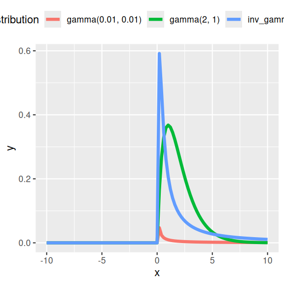

```r
standist::visualize("gamma(0.01, 0.01)", "gamma(2, 1)", "inv_gamma(0.4, 0.3)")
```

```r
peake_form <- bf(INDIV ~ scale(log(AREA)), family = negbinomial())
get_prior(peake_form, data = peake)
```

```
                  prior     class         coef group resp dpar nlpar lb ub
                 (flat)         b
                 (flat)         b scalelogAREA
 student_t(3, 5.8, 2.5) Intercept
    inv_gamma(0.4, 0.3)     shape                                     0
       source
      default
 (vectorized)
      default
      default
```

```r
priors <-
  prior(normal(6, 1.1), class = "Intercept") +
  prior(normal(0, 1.1), class = "b") +
  prior(gamma(0.01, 0.01), class = "shape")
## prior(gamma(2, 1), class='shape')
peake_brm4 <- brm(peake_form,
  data = peake,
  prior = priors,
  sample_prior = TRUE,
  iter = 5000, warmup = 1000,
  chains = 3, cores = 3,
  thin = 5, refresh = 0,
  backend = "rstan"
)
```

**Plotting prior and posterior**

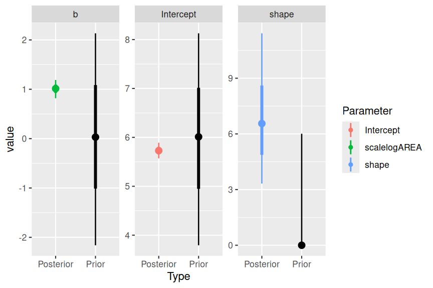

```r
peake_brm4 |> SUYR_prior_and_posterior()
```

**Conclusions:**

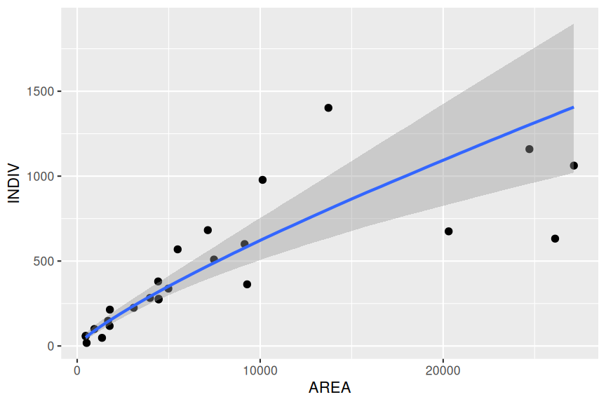

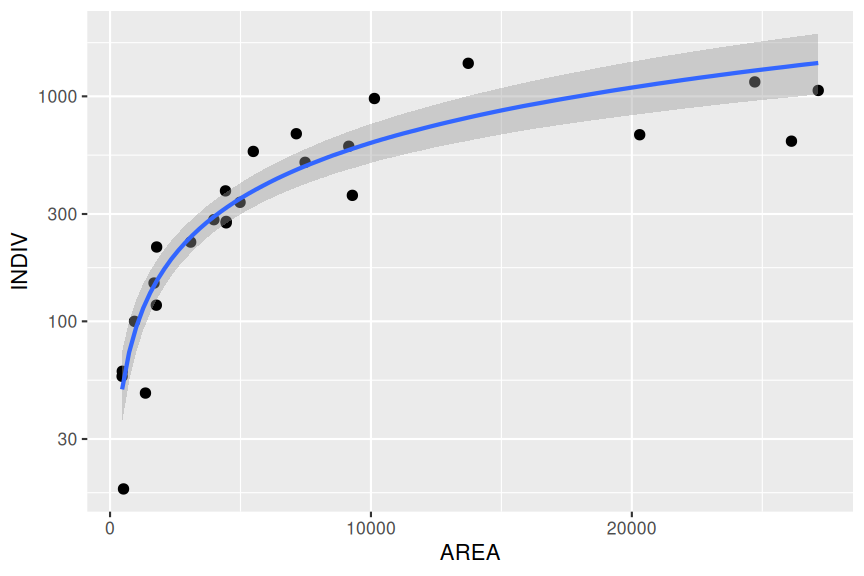

```r
peake_brm4 |>
  conditional_effects() |>
  plot(points = TRUE) |>
  _[[1]] + scale_y_log10()
```

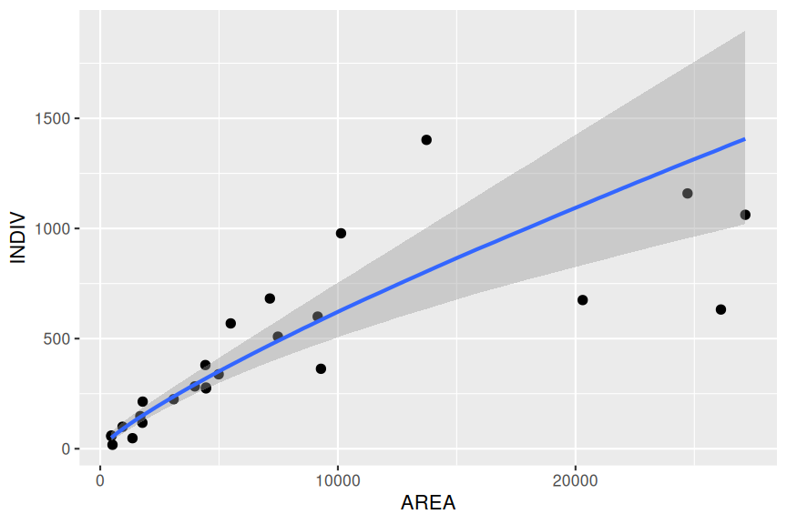

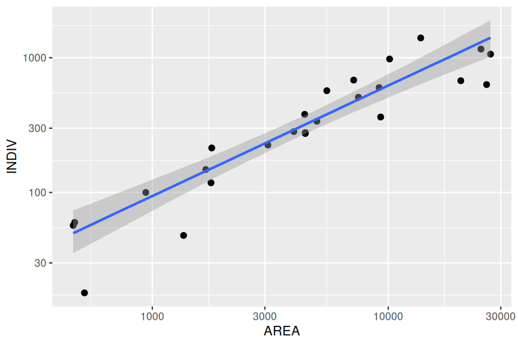

```r
peake_brm4 |>
  conditional_effects() |>
  plot(points = TRUE) |>
  _[[1]] + scale_y_log10() + scale_x_log10()
```

```
Data points may overlap. Use the `jitter` argument to add some amount of
  random variation to the location of data points and avoid overplotting.
```

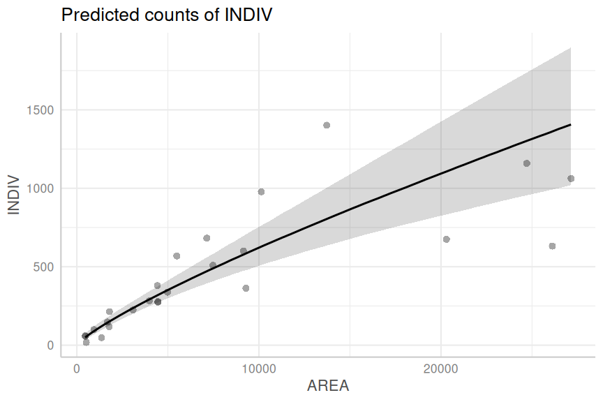

```r
## ggemmeans(peake_brm4,  ~AREA) |> plot(show_data=TRUE)
ggpredict(peake_brm4, ~AREA) |> plot(show_data = TRUE)
```

**MCMC chain and posterior checks**

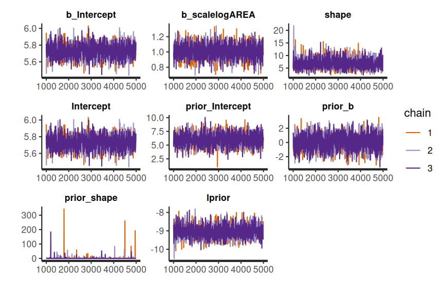

```r
peake_brm4$fit |> stan_trace()
```

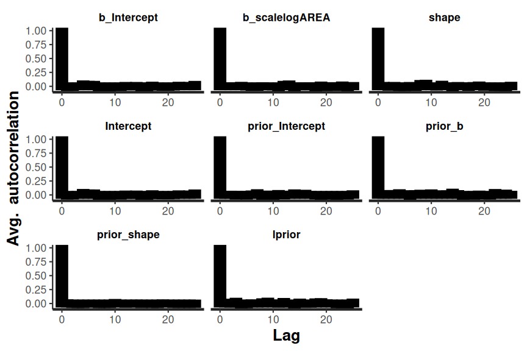

```r
peake_brm4$fit |> stan_ac()
```

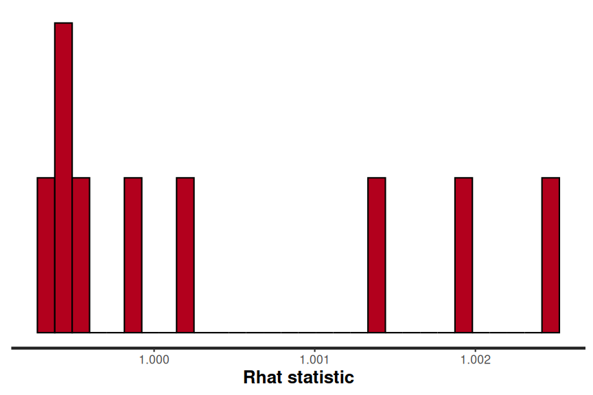

```r
peake_brm4$fit |> stan_rhat()
```

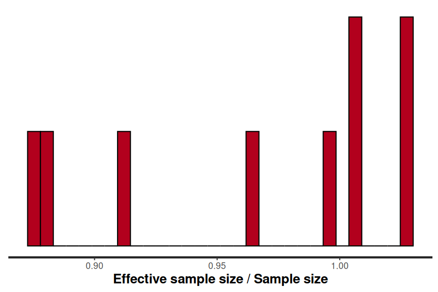

```r
peake_brm4$fit |> stan_ess()
```

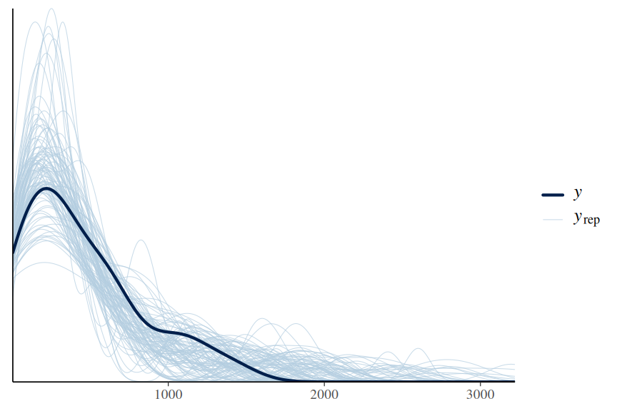

```r
pp_check(peake_brm4, x = "AREA", type = "dens_overlay", ndraws = 100)
```

```
Using all posterior draws for ppc type 'intervals' by default.
```

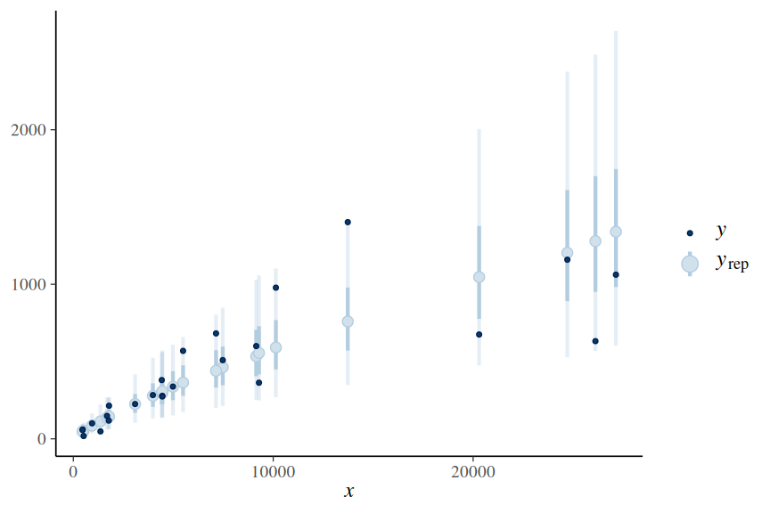

```r
pp_check(peake_brm4, x = "AREA", type = "intervals")
```

**DHARMa residuals**

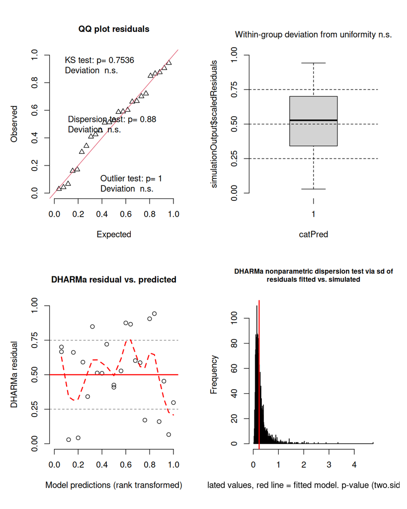

```r
peake_resids <- make_brms_dharma_res(peake_brm4, integerResponse = FALSE)
wrap_elements(~ testUniformity(peake_resids)) +
  wrap_elements(~ plotResiduals(peake_resids, form = factor(rep(1, nrow(peake))))) +
  wrap_elements(~ plotResiduals(peake_resids, quantreg = FALSE)) +
  wrap_elements(~ testDispersion(peake_resids))
```

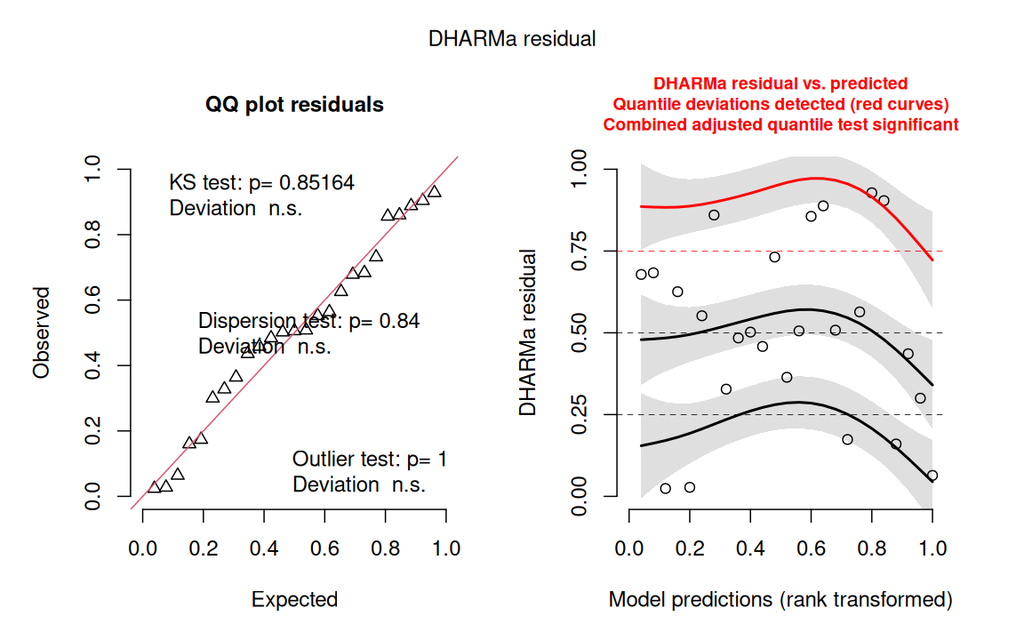

```r
preds <- posterior_predict(peake_brm4, ndraws = 250, summary = FALSE)
peake_resids <- createDHARMa(
  simulatedResponse = t(preds),
  observedResponse = peake$INDIV,
  fittedPredictedResponse = apply(preds, 2, median),
  integerResponse = TRUE
)
plot(peake_resids)
```

**LOOIC**

Different models can be compared via information criterion. LOO (Leave One Out) IC is similar to AIC except that AIC does not consider priors and assumes that the posterior likelihood is multivariate normal. LOO AIC does not and integrates over all uncertainty.

- ELPD: is the theoretical expected log pointwise predictive density for a new dataset and can be estimated via leave-one-out cross-validation.
- `elpd_loo`: is the Bayesian LOO estimate of ELPD
- `SE` of `elpd_loo`: is the Monte Carlo standard error is the estimate for the computational accuracy of MCMC and importance sampling used to compute `elpd_loo`
- `p_loo`: is the difference between `elpd_loo` and the estimated from non-cross validated ELPD and therefore is a measure of the relative extra difficulty of predicting new data compared to the observed data. It can also be a meaure of the effective number of parameters:
  - in a well behaved model, `p_loo` will be less than the number of estimated parameters and the total sample size.
  - in a misspecified model, `p_loo` will be greater than the number of estimated parameters and the total sample size.
- `Pareto k`: is a relative measure of the influence of each observation as well as the accuracy with which the associated leave one out calculations can be estimated.
  - when `k < 0.5`: the corresponding components can be accurately estimated
  - when `0.5 < k < 0.7`: the accuracy is lower but still acceptable
  - when `k>0.7`: the accuracy is too low and `elpd_loo` is unreliable. This can also suggest a misspecified model.

More information about the above can be gleaned from [https://mc-stan.org/loo/reference/loo-glossary.html].

Start with the Poisson model

```r
(peake_brm3.loo <- loo(peake_brm3))
```

```
Computed from 2400 by 25 log-likelihood matrix.

         Estimate    SE
elpd_loo   -934.4 300.1
p_loo       124.8  50.1
looic      1868.7 600.2
------
MCSE of elpd_loo is NA.
MCSE and ESS estimates assume MCMC draws (r_eff in [0.8, 1.0]).

Pareto k diagnostic values:
                         Count Pct.    Min. ESS
(-Inf, 0.7]   (good)     19    76.0%   111
   (0.7, 1]   (bad)       2     8.0%   <NA>
   (1, Inf)   (very bad)  4    16.0%   <NA>
See help('pareto-k-diagnostic') for details.
```

**Conclusions:**

- `p_loo` is substantially higher than the number of estimated parameters
- there are some `Pareto k` values identified as bad or even very bad

Now for the Negative Binomial model

```r
(peake_brm4.loo <- loo(peake_brm4))
```

```
Computed from 2400 by 25 log-likelihood matrix.

         Estimate   SE
elpd_loo   -156.3  5.8
p_loo         2.9  0.8
looic       312.7 11.6
------
MCSE of elpd_loo is 0.1.
MCSE and ESS estimates assume MCMC draws (r_eff in [0.9, 1.0]).

All Pareto k estimates are good (k < 0.7).
See help('pareto-k-diagnostic') for details.
```

**Conclusions:**

- `p_loo` is lower than the number of estimated parameters
- there are no bad `Pareto k` values

We can also compare the models.

The difference in Expected Log Pointwise Probability Density (`elpd_dff`) computes the difference in `elpd_loo` of two models (expressed relative to the higher model). The difference in `elpd_diff` will be negative if the expected out-of-sample predictive accuracy of the first model is higher. If the difference is be positive then the second model is preferred.

Note, the above assumes that both models are valid. In the current case, we know that the Poisson model was overdispersed and thus it should not be a genuine candidate. Nevertheless, we will compare the Poisson to the Negative Binomial for illustrative purposes.

```r
loo_compare(peake_brm3.loo, peake_brm4.loo)
```

```
           elpd_diff se_diff
peake_brm4    0.0       0.0
peake_brm3 -778.0     295.8
```

**Conclusions:**

- the `elpd_diff` is negative, indicating that the first model (Negative Binomial) is better.